# 2019年精细化网格预报检验评估总结

对2016-2019年的精细化网格预报进行较为全面检验评估, 用于2019年年终述职报告.

### Setup

```r
library(tidyverse)
library(ggplot2)
library(scales)
library(hrbrthemes)
library(showtext)

if (!knitr::is_latex_output()) {
  knitr::opts_chunk$set(dpi = 300, dev.args = list(type = "cairo"))
}
```

如何评估精细化网格预报产品质量: * 时间线对比, 历年产品质量变化曲线; * 价值链检查, 从数值模式、客观方法、主观修订、国家级指导到国省融合对比; * 价值提高率对比, 客观方法、国家指导或国省产品相对于模式的提高率变化; * 横向对比，相对与其他预报中心、公司的预报能力如何。

## 温度预报

分析日最高/低温度精细化网格预报结果, 分析表明: * 短期时段, 最高/低温度预报RMSE呈现下降趋势, 其中国家级指导预报下降趋势不明显, 国省融合产品下降显著; 国省融合产品优于国家级指导预报; 国家级和国省融合 相对于最优模式EC预报订正明显; * 中期时段, 最高/低温度预报RMSE呈现显著的年际变化, 无明显下降趋势; 国省融合产品在国家级指导预报上没有显著订正作用； 国家级和国省融合产品相对于GRAPES模式有明显订正作用， 但对于EC模式订正能力没有体现. *

```r
# set score data.frame
Temp_score = data.frame(
  Product = rep(c("GRAPES", "EC", "Guide_Grid", "Final_Grid"), 16),
  Year = rep(rep(c(2016, 2017, 2018, 2019), each=4), 4),
  Valid = rep(c(rep("1 Day", 16), rep("4 Day", 16)), 2),
  Element = c(rep("MaxTemp", 32), rep("MinTemp", 32)),
  RMSE = c(  NA, 3.42, 3.22,   NA,    NA, 3.52, 3.00, 3.04,
             NA, 3.52, 2.96, 2.85,  4.14, 3.43, 2.97, 2.74,

             NA, 3.60, 3.81,   NA,    NA, 3.74, 3.46, 4.04,
             NA, 3.73, 3.56, 3.35,  4.71, 3.74, 3.63, 4.03,

             NA, 2.66, 2.77,   NA,    NA, 2.73, 2.71, 2.84,
             NA, 2.77, 2.71, 2.59,  3.29, 2.75, 2.67, 2.45,

             NA, 2.88, 3.07,   NA,    NA, 2.93, 2.88, 3.06,
             NA, 2.99, 3.02, 2.72,  3.53, 2.97, 2.95, 3.11))

Temp_score$Product <- factor(Temp_score$Product,
                             levels = c("GRAPES", "EC", "Guide_Grid", "Final_Grid"))
```

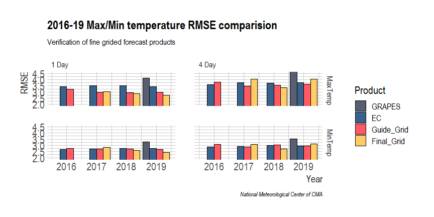

```r
ggplot(Temp_score, aes(Year, RMSE)) +
  geom_bar(aes(fill=Product), stat="identity", color="black", position=position_dodge()) +
  facet_grid(rows=vars(Element), cols=vars(Valid)) +
  scale_y_continuous(limits=c(2,4.5),oob = rescale_none) +
  scale_fill_manual(values=c("#595F72", "#38618C", "#FF5964", "#FFCC66")) +
  labs(title="2016-19 Max/Min temperature RMSE comparision",
       subtitle="Verification of fine grided forecast products",
       caption="National Meteorological Center of CMA")+
  theme_ipsum(base_size=16, axis_title_size=14)
```

## 降水预报

```r
# set score data.frame
Rain_score = data.frame(
  Product = rep(c("GRAPES", "EC", "Guide_Grid", "Final_Grid"), 16),
  Year = rep(rep(c(2016, 2017, 2018, 2019), each=4), 4),
  Valid = rep(c(rep("1 Day", 16), rep("4 Day", 16)), 2),
  Element = c(rep("≥0.1mm", 32), rep("≥50mm", 32)),
  ThreatScore = c(0.516, 0.507, 0.560, 0.528,  0.482, 0.506, 0.558, 0.547,
                  0.495, 0.502, 0.553, 0.547,  0.484, 0.511, 0.560, 0.556,

                  0.464, 0.475, 0.512,    NA,  0.438, 0.475, 0.506, 0.427,
                  0.455, 0.469, 0.487, 0.466,  0.438, 0.475, 0.501, 0.477,

                  0.139, 0.188, 0.213, 0.225,  0.076, 0.145, 0.177, 0.161,
                  0.100, 0.147, 0.172, 0.160,  0.108, 0.158, 0.199, 0.182,

                  0.046, 0.087, 0.085,    NA,  0.031, 0.077, 0.109, 0.102,
                  0.042, 0.061, 0.075, 0.053,  0.035, 0.086, 0.111, 0.083))

Rain_score$Product <- factor(Temp_score$Product,
                             levels = c("GRAPES", "EC", "Guide_Grid", "Final_Grid"))
```

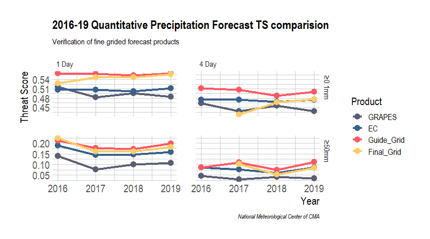

```r
ggplot(Rain_score, aes(Year, ThreatScore)) +
  geom_line(aes(color=Product), size=1.5) +
  geom_point(aes(color=Product), size=4) +
  facet_grid(rows=vars(Element), cols=vars(Valid), scales="free") +
  scale_color_manual(values=c("#595F72", "#38618C", "#FF5964", "#FFCC66")) +
  labs(x="Year", y="Threat Score",
       title="2016-19 Quantitative Precipitation Forecast TS comparision",
       subtitle="Verification of fine grided forecast products",
       caption="National Meteorological Center of CMA")+
  theme_ipsum(base_size=16, axis_title_size=16)
```

## 风速

```r
# set score data.frame
scores = data.frame(
  Product = rep(c("GRAPES", "Guide_Grid", "Final_Grid"), each=8),
  Year = rep(2019, 24),
  ForecastHour = rep(c(3, 6, 9, 12, 15, 18, 21, 24), 3),
  Element = rep("Wind Speed", 24),
  Accuracy = c(35.6255, 35.7276,    35.4112,    33.6232,    34.93,  35.2935,    34.939, 33.2292,
               44.1765, 43.7187,    43.1356,    44.2996,    43.7052,    43.4366,    42.8544,    43.8074,
               40.3553, 40.1926,    39.8057,    40.1577,    40.1992,    39.8332,    39.453, 38.6807))

scores$Product <- factor(scores$Product, levels = c("GRAPES", "Guide_Grid", "Final_Grid"))
```

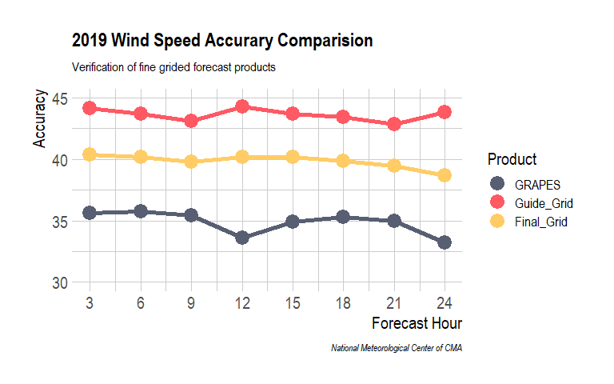

```r
ggplot(scores, aes(ForecastHour, Accuracy)) +
  geom_line(aes(color=Product), size=2) +
  geom_point(aes(color=Product), size=6) +
  scale_color_manual(values=c("#595F72", "#FF5964", "#FFCC66")) +
  scale_x_continuous(breaks=c(3, 6, 9, 12, 15, 18, 21, 24)) +
  ylim(c(30, 45)) +
  labs(x="Forecast Hour", y="Accuracy",
       title="2019 Wind Speed Accurary Comparision",
       subtitle="Verification of fine grided forecast products",
       caption="National Meteorological Center of CMA")+
  theme_ipsum(base_size=16, axis_title_size=16)
```

## 能见度

```r
# set score data.frame
scores = data.frame(
  Product = rep(c("EC", "Guide_Grid", "Final_Grid"), each=8),
  Year = rep(2019, 24),
  ForecastHour = rep(c(3, 6, 9, 12, 15, 18, 21, 24), 3),
  Element = rep("Visibility", 24),
  ThreatScore = c(0.153,    0.168,  0.179,  0.158,  0.155,  0.170,  0.180,  0.159,
                  0.276,    0.308,  0.346,  0.316,  0.273,  0.311,  0.348,  0.315,
                  0.198,    0.202,  0.223,  0.226,  0.197,  0.202,  0.224,  0.226))

scores$Product <- factor(scores$Product, levels = c("EC", "Guide_Grid", "Final_Grid"))
```

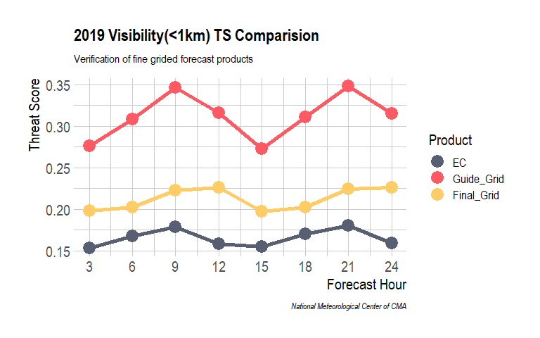

```r
ggplot(scores, aes(ForecastHour, ThreatScore)) +
  geom_line(aes(color=Product), size=2) +
  geom_point(aes(color=Product), size=6) +
  scale_x_continuous(breaks=c(3, 6, 9, 12, 15, 18, 21, 24)) +
  scale_color_manual(values=c("#595F72", "#FF5964", "#FFCC66")) +
  labs(x="Forecast Hour", y="Threat Score",
       title="2019 Visibility(<1km) TS Comparision",
       subtitle="Verification of fine grided forecast products",
       caption="National Meteorological Center of CMA")+
  theme_ipsum(base_size=16, axis_title_size=16)
```

## 相对湿度

```r
# set score data.frame
scores = data.frame(
  Product = rep(c("GRAPES", "Guide_Grid", "Final_Grid"), each=8),
  Year = rep(2019, 24),
  ForecastHour = rep(c(3, 6, 9, 12, 15, 18, 21, 24), 3),
  Element = rep("Visibility", 24),
  MAE = c(13.1028,  12.7723,    14.115, 13.8174,    13.2651,    12.9129,    13.9696,    13.5812,
          11.8964,  11.9248,    11.7291,    11.6258,    12.0646,    12.392, 12.1623,    14.0856,
          12.5057,  12.7205,    12.6952,    12.5116,    12.8254,    13.1604,    13.1057,    13.0282))

scores$Product <- factor(scores$Product, levels = c("GRAPES", "Guide_Grid", "Final_Grid"))
```

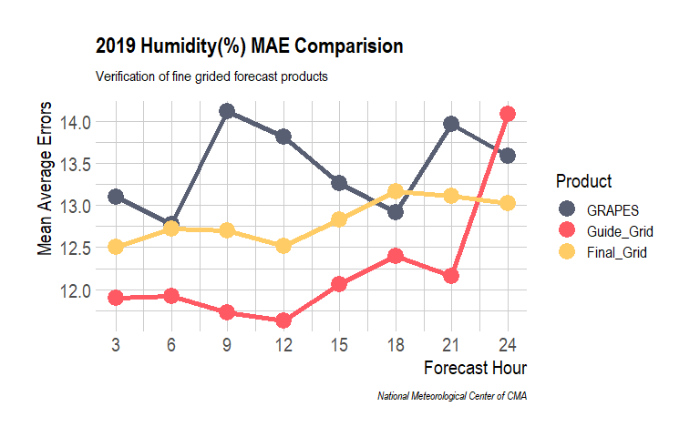

```r
ggplot(scores, aes(ForecastHour, MAE)) +
  geom_line(aes(color=Product), size=2) +
  geom_point(aes(color=Product), size=6) +
  scale_x_continuous(breaks=c(3, 6, 9, 12, 15, 18, 21, 24)) +
  scale_color_manual(values=c("#595F72", "#FF5964", "#FFCC66")) +
  labs(x="Forecast Hour", y="Mean Average Errors",
       title="2019 Humidity(%) MAE Comparision",
       subtitle="Verification of fine grided forecast products",
       caption="National Meteorological Center of CMA")+
  theme_ipsum(base_size=16, axis_title_size=16)
```